# Multi-Level Regression and Poststratification Tutorial

### Introduction

It is often of interest to researchers to look into state-level opinion, in addition to or instead of national-level opinions prior to elections. However, finding surveys that are uniform across all or most states is extremely challenging. One method of estimating state-level opinion using national survey data is called **multilevel modeling with poststratification**. This method begins by using multilevel regression to model individual survey responses as a function of demographic and geographic predictors, partially pooling respondents across states to an extent determined by the data. The final step is poststratification, in which the estimates for each demographic-geographic respondent type are weighted (poststratified) by the percentages of each type in the actual state populations.

In this tutorial, we will be going to through a tutorial for implementing this method, and then explore a Bayesian version of it.

### The Data

Obtain the three data sets from the following link: [MRP Primer](http://www.princeton.edu/~jkastell/mrp_primer.html)

```r
# importing packages

library("arm")
library("foreign")
```

### Step 1: Gather National Opinion Poll(s)

These polls should include some respondent demographic information and some type of geographic indicator such as state. In this tutorial we’ll be using the “gay_marriage_megapoll.dta” set which contains five national polls that were conducted in 2004.

### Step 2: If necessary, recode these polls so that they can be combined into a single internally-consistent dataset.

For this step, you may rename columns so that the data sets can be merged properly. For our dataset this has already been completed.

```r
#read in megapoll and attach
marriage.data <- read.dta("gay_marriage_megapoll.dta",
          convert.underscore = TRUE) #convert variables names with underscores to periods
```

### Step 3: Create A Separate Dataset of State-Level Predictors

We may wish to model state-level effects in our multilevel regression. To do this we will use state-level predictiors, e.g. region/state-level demographics. This will reduce the unexplained group level variation. In this tutorial, we already have a data set with state-level information in it.

```r
#read in state-level dataset
Statelevel <- read.dta("state_level_update.dta",convert.underscore = TRUE)
Statelevel <- Statelevel[order(Statelevel$sstate.initnum),]
```

### Step 4: Collecting census data to enable poststratificaiton

We will need census data to complete the poststratification later in the tutorial. This data must correspond to all individual-level demographic variables included in our model. Ultimately, we need a dataset of the population counts for each demographic-state type, e.g. how many African Americans between 18-25 went to college and reside in North Carolina. For this tutorial, we will use the 5% Public Use Microdata Sample from the 2000 census.

```r
#read in Census data
Census <- read.dta("poststratification 2000.dta",convert.underscore = TRUE)
Census <- Census[order(Census$cstate),]
Census$cstate.initnum <-  match(Census$cstate, Statelevel$sstate)
```

### Step 5: Creating Index Variables

Next we will create index variables so that we can use our individual-level model and in the poststratification step.

```r
# Create index variables

#At level of megapoll

marriage.data$race.female <- (marriage.data$female *3) + marriage.data$race.wbh# from 1 for white males to 6 for hispanic females
marriage.data$age.edu.cat <- 4 * (marriage.data$age.cat -1) + marriage.data$edu.cat# from 1 for 18-29 with low edu to 16 for 65+ with high edu
marriage.data$p.evang.full <- Statelevel$p.evang[marriage.data$state.initnum]# proportion of evangelicals in respondent's state
marriage.data$p.mormon.full <-Statelevel$p.mormon[marriage.data$state.initnum]# proportion of mormon's in respondent's state
marriage.data$p.relig.full <- marriage.data$p.evang.full + marriage.data$p.mormon.full# combined evangelical + mormom proportions
marriage.data$p.kerry.full <- Statelevel$kerry.04[marriage.data$state.initnum]# kerry's % of 2-party vote in respondent's state in 2004

#At census level (same coding as above for all variables)

Census$crace.female <- (Census$cfemale *3) + Census$crace.WBH
Census$cage.edu.cat <- 4 * (Census$cage.cat -1) + Census$cedu.cat
Census$cp.evang.full<-  Statelevel$p.evang[Census$cstate.initnum]
Census$cp.mormon.full <- Statelevel$p.mormon[Census$cstate.initnum]
Census$cp.relig.full <- Census$cp.evang.full + Census$cp.mormon.full
Census$cp.kerry.full <-  Statelevel$kerry.04[Census$cstate.initnum]
```

### Step 6: Fitting our individual-level regression model.

Now we are ready to fit a regression model for an individual survey response on gay marriage rights given demographics and geography, i.e. each individual’s response will be a function of their demographics and state. We’ll denote each individual as *i* with indices *j, k, l, m, s,* and *p* for race-gender combination, age category, education category, region, state, and poll respectively, and including an age-education interaction. More specifically, we denote $y_i$ as 1 for supporters of same- sex marriage and 0 for opponents and those with no opinion. Remember that since we’re modeling a binary variables we ought to use logistic regression, and thus our model will be as follows:

$$\mathrm{Pr}(y_i = 1) = \mathrm{logit}^{-1}(\beta^0 + \alpha^{race,gender}_{j[i]} + \alpha^{age}_{k[i]} + \alpha^{edu}_{l[i]} + \alpha^{age,edu}_{k[i],l[i]} + \alpha^{state}_{s[i]} + \alpha^{year}_{p[i]})$$

We can think of the terms after the intercept as modeled effects for different groups of respondents such as individuals who are a specific age. All of them except the state coefficient will be model as drawn from a normal distribution with mean zero and some estimated variance specific to that variable. For example,

$$\alpha^{poll}_p \sim N(0, \sigma^2_{poll}), \mathrm{p = 1, ..., n}$$

For the state effect, we’ll be doing something slightly different. Instead of having a distribution with mean equaling zero, we will be modeling it as a function of the the region into which the state falls and the state’s conservative religious percentage and Democratic 2004 presidential vote share:[^1]

$$\alpha^{state}_s \sim N(\alpha^{region}_{m[s]} + \beta^{relig}\cdot relig_s + \beta^{presvote} \cdot presvote_s, \sigma^2_{state}), \mathrm{s = 1, ..., 51}$$

(Note: we model the region variable identically to the previous variables, e.g. poll.)

Now we’re ready to move onto coding up this model:

```r
#run individual-level opinion model

individual.model <- glmer(formula = yes.of.all ~ (1|race.female) + (1|age.cat) + (1|edu.cat) + (1|age.edu.cat) + (1|state) + (1|region) + (1|poll) + p.relig.full + p.kerry.full,data=marriage.data, family=binomial(link="logit")) # Note: (1|variable) denotes a random effect
display(individual.model)
```

```
## glmer(formula = yes.of.all ~ (1 | race.female) + (1 | age.cat) +
##     (1 | edu.cat) + (1 | age.edu.cat) + (1 | state) + (1 | region) +
##     (1 | poll) + p.relig.full + p.kerry.full, data = marriage.data,
##     family = binomial(link = "logit"))
##              coef.est coef.se
## (Intercept)  -1.41     0.54
## p.relig.full -0.02     0.00
## p.kerry.full  0.02     0.01
##
## Error terms:
##  Groups      Name        Std.Dev.
##  state       (Intercept) 0.04
##  age.edu.cat (Intercept) 0.09
##  race.female (Intercept) 0.23
##  poll        (Intercept) 0.21
##  region      (Intercept) 0.20
##  edu.cat     (Intercept) 0.36
##  age.cat     (Intercept) 0.55
##  Residual                1.00
## ---
## number of obs: 6341, groups: state, 49; age.edu.cat, 16; race.female, 6; poll, 5; region, 5; edu.cat, 4; age.cat, 4
## AIC = 7459.4, DIC = 7276
## deviance = 7357.7
```

```r
#examine random effects and standard errors for race-female
ranef(individual.model)$race.female
```

```
##   (Intercept)
## 1 -0.21041983
## 2 -0.08701354
## 3  0.04904947
## 4  0.23019628
## 5 -0.22601715
## 6  0.24576228
```

```r
se.ranef(individual.model)$race.female
```

```
##   (Intercept)
## 1   0.1083278
## 2   0.1454986
## 3   0.1472982
## 4   0.1080311
## 5   0.1362828
## 6   0.1485565
```

```r
# Since we do not have any respondents from Alaska or Hawaii, we have to create a vector of state random effects that accounts for these states.
state.ranefs <- array(NA,c(51,1))
dimnames(state.ranefs) <- list(c(Statelevel$sstate),"effect")
for(i in Statelevel$sstate){
  state.ranefs[i,1] <- ranef(individual.model)$state[i,1]
}
state.ranefs[,1][is.na(state.ranefs[,1])] <- 0 #set states with missing REs (b/c not in data) to zero
```

This logistic regression gives the probability that any adult will support same-sex marriage given the person’s sex, race, age, education, and state.

### Step 7: Poststatify the demographic-geographic types

To complete this method, we need to compute a weighted average of the probabilities from the logistic regression to estimate the proportin of same-sex marriage supporters in each state. First, need to create a prediction for each demographic-state combination (each cell in Census data):

```r
#create a prediction for each cell in Census data
cellpred <- invlogit(fixef(individual.model)["(Intercept)"]
                     +ranef(individual.model)$race.female[Census$crace.female,1]
                     +ranef(individual.model)$age.cat[Census$cage.cat,1]
                     +ranef(individual.model)$edu.cat[Census$cedu.cat,1]
                     +ranef(individual.model)$age.edu.cat[Census$cage.edu.cat,1]
                     +state.ranefs[Census$cstate,1]
                     +ranef(individual.model)$region[Census$cregion,1]
                     +(fixef(individual.model)["p.relig.full"] *Census$cp.relig.full)
                     +(fixef(individual.model)["p.kerry.full"] *Census$cp.kerry.full)
)
```

More concretely, we would compute this using the following code:

```r
#weights the prediction by the freq of cell
cellpredweighted <- cellpred * Census$cpercent.state

#calculates the percent within each state (weighted average of responses)
statepred <- 100* as.vector(tapply(cellpredweighted,Census$cstate,sum))
statepred
```

```
##  [1] 35.68605 18.34818 19.56874 38.62509 45.52374 41.87638 42.97196
##  [8] 51.11665 34.60457 28.89359 24.00980 43.09559 32.24169 27.06452
## [15] 35.83593 27.64564 27.39420 21.23864 24.50546 47.08487 35.18203
## [22] 40.57050 33.87580 34.42007 27.23455 19.27549 34.98474 24.97002
## [29] 27.99880 26.04115 41.51005 42.01405 40.39234 40.00020 44.13284
## [36] 32.80594 18.08791 40.87434 37.88619 45.17418 22.35097 27.55108
## [43] 21.27458 24.61370 19.00481 28.81052 44.69614 43.00388 32.69952
## [50] 27.27826 30.16835
```

This result is a set a state-level opinion estimates that you could use to help make predictions regarding the election.

### Bayesian Model

```r
library(rstan)
library(brms)

# the model
bayes.mod <- brm(yes.of.all ~ (1|race.female) + (1|age.cat) + (1|edu.cat)
                 + (1|age.edu.cat) + (1|state) + (1|region)
                 + p.relig.full + p.kerry.full,
                 data=marriage.data, family=bernoulli(),
                 prior=c(set_prior("normal(0,0.2)", class='b'),
                         set_prior("normal(0,0.2)", class='sd', group="race.female"),
                         set_prior("normal(0,0.2)", class='sd', group="age.cat"),
                         set_prior("normal(0,0.2)", class='sd', group="edu.cat"),
                         set_prior("normal(0,0.2)", class='sd', group="age.edu.cat"),
                         set_prior("normal(0,0.2)", class='sd', group="state"),
                         set_prior("normal(0,0.2)", class='sd', group="region")))
```

[output not shown]

[output cut: 40 more lines]

[output not shown]

```r
summary(bayes.mod)
```

```
##  Family: bernoulli
##   Links: mu = logit
## Formula: yes.of.all ~ (1 | race.female) + (1 | age.cat) + (1 | edu.cat) + (1 | age.edu.cat) + (1 | state) + (1 | region) + p.relig.full + p.kerry.full
##    Data: marriage.data (Number of observations: 6341)
## Samples: 4 chains, each with iter = 2000; warmup = 1000; thin = 1;
##          total post-warmup samples = 4000
##
## Group-Level Effects:
## ~age.cat (Number of levels: 4)
##               Estimate Est.Error l-95% CI u-95% CI Eff.Sample Rhat
## sd(Intercept)     0.42      0.09     0.27     0.63       4000 1.00
##
## ~age.edu.cat (Number of levels: 16)
##               Estimate Est.Error l-95% CI u-95% CI Eff.Sample Rhat
## sd(Intercept)     0.10      0.06     0.01     0.23       1572 1.00
##
## ~edu.cat (Number of levels: 4)
##               Estimate Est.Error l-95% CI u-95% CI Eff.Sample Rhat
## sd(Intercept)     0.32      0.09     0.17     0.53       4000 1.00
##
## ~race.female (Number of levels: 6)
##               Estimate Est.Error l-95% CI u-95% CI Eff.Sample Rhat
## sd(Intercept)     0.23      0.08     0.12     0.42       4000 1.00
##
## ~region (Number of levels: 5)
##               Estimate Est.Error l-95% CI u-95% CI Eff.Sample Rhat
## sd(Intercept)     0.22      0.08     0.10     0.42       4000 1.00
##
## ~state (Number of levels: 49)
##               Estimate Est.Error l-95% CI u-95% CI Eff.Sample Rhat
## sd(Intercept)     0.06      0.04     0.00     0.16       1820 1.00
##
## Population-Level Effects:
##              Estimate Est.Error l-95% CI u-95% CI Eff.Sample Rhat
## Intercept       -1.48      0.52    -2.49    -0.48       3090 1.00
## p.relig.full    -0.01      0.01    -0.02    -0.00       4000 1.00
## p.kerry.full     0.02      0.01     0.00     0.03       4000 1.00
##
## Samples were drawn using sampling(NUTS). For each parameter, Eff.Sample
## is a crude measure of effective sample size, and Rhat is the potential
## scale reduction factor on split chains (at convergence, Rhat = 1).
```

```r
# Model Uncertainity: standard deviation of group-level intercepts
# install.packages("devtools")
# devtools::install_github("mjskay/tidybayes")
library(tidybayes)
approx_sd <- broom::tidy(individual.model) %>%
  filter(stringr::str_detect(term, "sd_"))
```

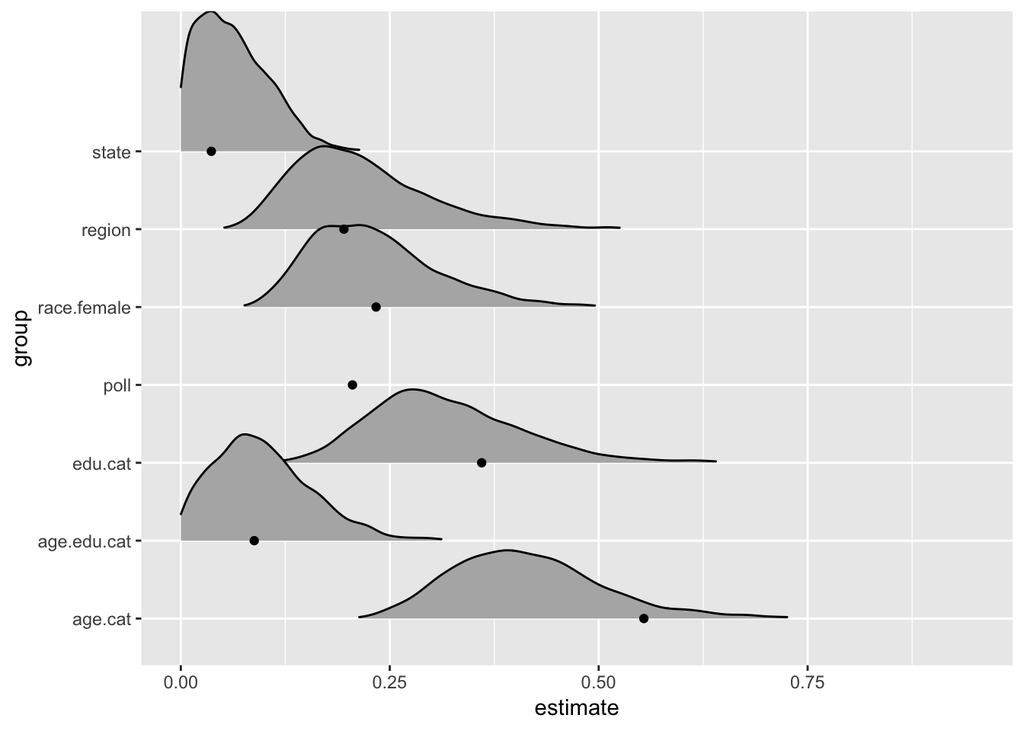

```r
bayes.mod %>%
  gather_samples(`sd_.*`, regex=TRUE) %>%
  ungroup() %>%
  mutate(group = stringr::str_replace_all(term, c("sd_" = "","__Intercept"=""))) %>%
  ggplot(aes(y=group, x = estimate)) +
  ggridges::geom_density_ridges(aes(height=..density..),
                                rel_min_height = 0.01, stat = "density",
                                scale=1.5) +
  geom_point(data=approx_sd)
```

```r
# Edit Census data for use
Census$p.relig.full <- Census$cp.relig.full
Census$p.kerry.full <-  Census$cp.kerry.full

# point estimate for the level of state support for gay marriage and poststratify
ps.bayes.mod <- bayes.mod %>%
  add_predicted_draws(newdata=Census, allow_new_levels=TRUE) %>%
  rename(support = .prediction) %>%
  mean_qi() %>%
  mutate(support = support * cpercent.state) %>%
  group_by(cstate) %>%
  summarise(support = sum(support))
```

[^1]: These are just some examples of group-level predictors which reduce unexplained group-level variation, and thus lead to more precise estimation (Gelman and Hill 2007, 271)